# CreditCard Users Churn Prediction

#### This is the best model so far- XGboost with GridSearchCV

## XGBOOST with RandomizedSearchCV

```python
%%time

# Creating pipeline
pipe = make_pipeline(StandardScaler(), XGBClassifier(random_state=1))

# Parameter grid to pass in GridSearchCV
parameters = {'xgbclassifier__n_estimators': [75,100,125,150],
              'xgbclassifier__subsample':[0.7, 0.8, 0.9, 1],
              'xgbclassifier__gamma':[0, 1, 3, 5],
              'xgbclassifier__colsample_bytree':[0.7, 0.8, 0.9, 1]
              }

# Type of scoring used to compare parameter combinations
scorer = metrics.make_scorer(metrics.recall_score)

# Calling GridSearchCV
randomized_cv = RandomizedSearchCV(estimator=pipe, param_distributions=parameters,n_iter=50, scoring=scorer, cv=5, random_state=7)

# Fitting parameters in GridSeachCV
randomized_cv.fit(X_train, y_train)

print("Best Parameters:{} \nScore: {}".format(randomized_cv.best_params_, randomized_cv.best_score_))
```

[output not shown]

[output cut: 237 more lines]

## The RandomizedSearchCV completed in 1 minute 18 seconds

```python
randomized_cv.best_estimator_
```

```
Pipeline(steps=[('standardscaler', StandardScaler()),
                ('xgbclassifier',
                 XGBClassifier(base_score=0.5, booster='gbtree',
                               colsample_bylevel=1, colsample_bynode=1,
                               colsample_bytree=0.7, gamma=0, gpu_id=-1,
                               importance_type='gain',
                               interaction_constraints='',
                               learning_rate=0.300000012, max_delta_step=0,
                               max_depth=6, min_child_weight=1, missing=nan,
                               monotone_constraints='()', n_estimators=125,
                               n_jobs=16, num_parallel_tree=1, random_state=1,
                               reg_alpha=0, reg_lambda=1, scale_pos_weight=1,
                               subsample=0.7, tree_method='exact',
                               validate_parameters=1, verbosity=None))])
```

```python
xgb_classifier_tuned2 = randomized_cv.best_estimator_

xgb_classifier_tuned2.fit(X_train, y_train)
```

[output not shown]

```
Pipeline(steps=[('standardscaler', StandardScaler()),
                ('xgbclassifier',
                 XGBClassifier(base_score=0.5, booster='gbtree',
                               colsample_bylevel=1, colsample_bynode=1,
                               colsample_bytree=0.7, gamma=0, gpu_id=-1,
                               importance_type='gain',
                               interaction_constraints='',
                               learning_rate=0.300000012, max_delta_step=0,
                               max_depth=6, min_child_weight=1, missing=nan,
                               monotone_constraints='()', n_estimators=125,
                               n_jobs=16, num_parallel_tree=1, random_state=1,
                               reg_alpha=0, reg_lambda=1, scale_pos_weight=1,
                               subsample=0.7, tree_method='exact',
                               validate_parameters=1, verbosity=None))])
```

```
Accuracy on training set :  1.0
Accuracy on test set :  0.9684106614017769
Recall on training set :  1.0
Recall on test set :  0.8709016393442623
Precision on training set :  1.0
Precision on test set :  0.9279475982532751
```

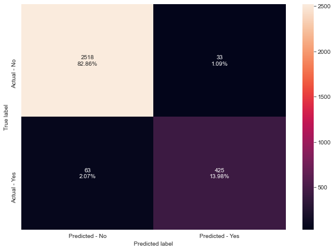

```python
# Calculating different metrics
get_metrics_score(xgb_classifier_tuned2,X_train,X_test,y_train,y_test)

# Creating confusion matrix
make_confusion_matrix(xgb_classifier_tuned2, y_test)
```

**Insights:**

- This is second besst model after XGBoost with Grid Search CV.
- the time difefrent between Grid Search Cv and Random CV is subtantial. The first took almost 7 minutes and the latter complted in 1 minute.
- The performance differeence is very small and can be neglected as well. </b>

## AdaBoost with GridSearchCV

```python
%%time

# Creating pipeline
pipe = make_pipeline(StandardScaler(), AdaBoostClassifier(random_state=1))

# Parameter grid to pass in GridSearchCV
param_grid = {
    "adaboostclassifier__n_estimators": np.arange(10, 110, 10),
    "adaboostclassifier__learning_rate": [0.1, 0.01, 0.2, 0.05, 1],
    "adaboostclassifier__base_estimator": [
        DecisionTreeClassifier(max_depth=2, random_state=1),
        DecisionTreeClassifier(max_depth=3, random_state=1),
    ],
}

# Type of scoring used to compare parameter combinations
scorer = metrics.make_scorer(metrics.recall_score)

# Calling GridSearchCV
grid_cv = GridSearchCV(estimator=pipe, param_grid=param_grid, scoring=scorer, cv=5)

# Fitting parameters in GridSeachCV
grid_cv.fit(X_train, y_train)

print(
    "Best Parameters:{} \nScore: {}".format(grid_cv.best_params_, grid_cv.best_score_)
)
```

```
Best Parameters:{'adaboostclassifier__base_estimator': DecisionTreeClassifier(max_depth=2, random_state=1), 'adaboostclassifier__learning_rate': 1, 'adaboostclassifier__n_estimators': 50}
Score: 0.8893809413401345
Wall time: 4min 34s
```

## The GridSearchCV completed in 4 minutes 34 seconds

```python
grid_cv.best_estimator_
```

```
Pipeline(steps=[('standardscaler', StandardScaler()),
                ('adaboostclassifier',
                 AdaBoostClassifier(base_estimator=DecisionTreeClassifier(max_depth=2,
                                                                          random_state=1),
                                    learning_rate=1, random_state=1))])
```

```python
ada_classifier_tuned1 = grid_cv.best_estimator_

ada_classifier_tuned1.fit(X_train, y_train)
```

```
Pipeline(steps=[('standardscaler', StandardScaler()),
                ('adaboostclassifier',
                 AdaBoostClassifier(base_estimator=DecisionTreeClassifier(max_depth=2,
                                                                          random_state=1),
                                    learning_rate=1, random_state=1))])
```

```
Accuracy on training set :  0.9864559819413092
Accuracy on test set :  0.9611714379730174
Recall on training set :  0.9499561018437226
Recall on test set :  0.8442622950819673
Precision on training set :  0.9652096342551294
Precision on test set :  0.9074889867841409
```

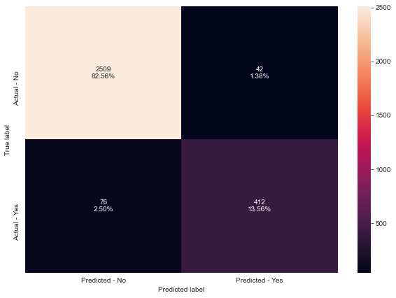

```python
# Calculating different metrics
get_metrics_score(ada_classifier_tuned1,X_train,X_test,y_train,y_test)

# Creating confusion matrix
make_confusion_matrix(ada_classifier_tuned1, y_test)
```

**Insights**:

- The performance of Adaboost with grid searchCV is slightly less than XGboost with grid Search CV

## AdaBoost with RandomizedSearchCV

```python
%%time

# Creating pipeline
pipe = make_pipeline(StandardScaler(), AdaBoostClassifier(random_state=1))

# Parameter grid to pass in GridSearchCV
param_grid = {
    "adaboostclassifier__n_estimators": np.arange(10, 110, 10),
    "adaboostclassifier__learning_rate": [0.1, 0.01, 0.2, 0.05, 1],
    "adaboostclassifier__base_estimator": [
        DecisionTreeClassifier(max_depth=2, random_state=1),
        DecisionTreeClassifier(max_depth=3, random_state=1),
    ],
}
# Type of scoring used to compare parameter combinations
scorer = metrics.make_scorer(metrics.recall_score)

#Calling RandomizedSearchCV
abc_tuned2 = RandomizedSearchCV(estimator=pipe, param_distributions=param_grid, n_iter=50, scoring=scorer, cv=5, random_state=1)

#Fitting parameters in RandomizedSearchCV
abc_tuned2.fit(X_train,y_train)

print("Best parameters are {} with CV score={}:" .format(abc_tuned2.best_params_,abc_tuned2.best_score_))
```

```
Best parameters are {'adaboostclassifier__n_estimators': 50, 'adaboostclassifier__learning_rate': 1, 'adaboostclassifier__base_estimator': DecisionTreeClassifier(max_depth=2, random_state=1)} with CV score=0.8893809413401345:
Wall time: 2min 22s
```

## The RandomizedSearchCV completed in 2 minute 22 seconds

```python
abc_tuned2.best_estimator_
```

```
Pipeline(steps=[('standardscaler', StandardScaler()),
                ('adaboostclassifier',
                 AdaBoostClassifier(base_estimator=DecisionTreeClassifier(max_depth=2,
                                                                          random_state=1),
                                    learning_rate=1, random_state=1))])
```

```python
ada_classifier_tuned2 = abc_tuned2.best_estimator_

ada_classifier_tuned2.fit(X_train, y_train)
```

```
Pipeline(steps=[('standardscaler', StandardScaler()),
                ('adaboostclassifier',
                 AdaBoostClassifier(base_estimator=DecisionTreeClassifier(max_depth=2,
                                                                          random_state=1),
                                    learning_rate=1, random_state=1))])
```

[output not shown]

[figure not shown]

```python
# Calculating different metrics
get_metrics_score(ada_classifier_tuned2,X_train,X_test,y_train,y_test)

# Creating confusion matrix
make_confusion_matrix(ada_classifier_tuned2, y_test)
```

### Feature importance

```python
def feat_importance(model, X_Train):
    fi = pd.DataFrame()
    fi['Col'] = X_train.columns
    fi['imp'] = np.round(abs(model[1].feature_importances_),4)
    fi = fi.sort_values(by='imp')
    plt.figure(figsize=(16,14))
    plt.barh(fi['Col'], fi['imp'], color='violet', align='center')
    plt.title('FEATURE IMPORTANCE')
    plt.show()
```

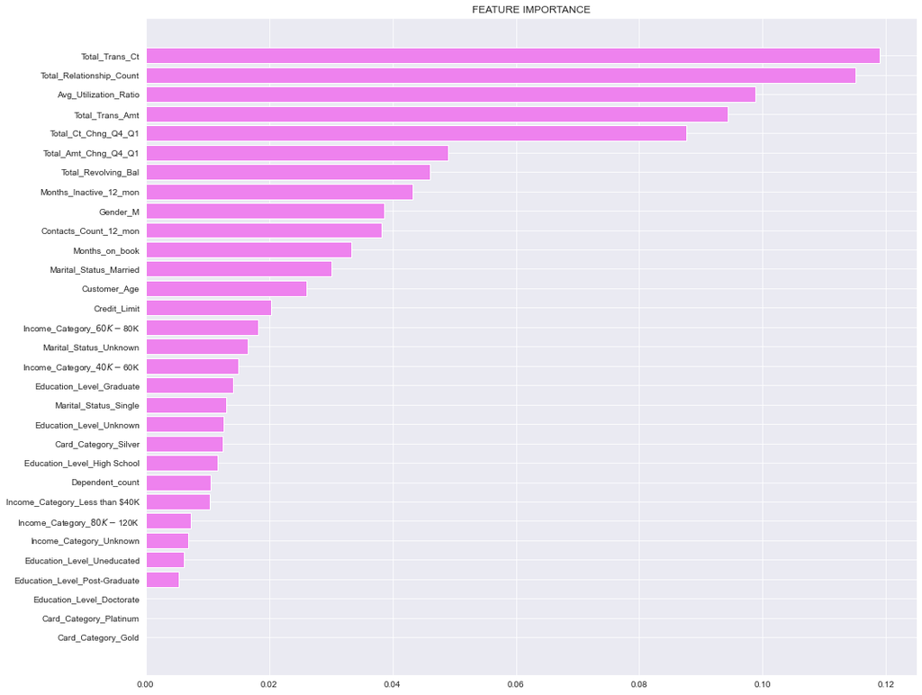

```python
feat_importance(xgb_classifier_tuned1, X_train)
```

**Insights**:

- Total_Trans_Ct: This is strong feature, customers with more transactiosn are less likely to leave
- Total_Relationship_Count: this feature is seond most important to the model, customer with more products and extrenely less are less likely to leave
- Total_Trans_Amt: customers with more amoount are less likely to leave

# Comparing all models

```python
# defining list of models
models = [xgb_classifier_tuned1, xgb_classifier_tuned2,ada_classifier_tuned1,ada_classifier_tuned2]

# defining empty lists to add train and test results
acc_train = []
acc_test = []
recall_train = []
recall_test = []
precision_train = []
precision_test = []

# looping through all the models to get the metrics score - Accuracy, Recall and Precision
for model in models:

    #print(model)
    j = get_metrics_score(model,X_train,X_test,y_train,y_test, False)
    #print(j)
    acc_train.append(j[0])
    acc_test.append(j[1])
    recall_train.append(j[2])
    recall_test.append(j[3])
    precision_train.append(j[4])
    precision_test.append(j[5])
```

```python
comparison_frame = pd.DataFrame(
    {
        "Model": [
            "XGBoost with GridSearchCV",
            "XGBoost with RandomizedSearchCV",
            "AdaBoost with GridSearchCV",
            "AdaBoost with RandomizedSearchCV"
        ],
        "Train_Accuracy": acc_train,
        "Test_Accuracy": acc_test,
        "Train_Recall": recall_train,
        "Test_Recall": recall_test,
        "Train_Precision": precision_train,
        "Test_Precision": precision_test,
    }
)

# Sorting models in decreasing order of test recall
comparison_frame.sort_values(by="Test_Recall", ascending=False)
```

|  | Model | Train_Accuracy | Test_Accuracy | Train_Recall | Test_Recall | Train_Precision | Test_Precision |
| --- | --- | --- | --- | --- | --- | --- | --- |
| 0 | XGBoost with GridSearchCV | 1.000000 | 0.974334 | 1.000000 | 0.883197 | 1.00000 | 0.953540 |
| 1 | XGBoost with RandomizedSearchCV | 1.000000 | 0.968411 | 1.000000 | 0.870902 | 1.00000 | 0.927948 |
| 2 | AdaBoost with GridSearchCV | 0.986456 | 0.961171 | 0.949956 | 0.844262 | 0.96521 | 0.907489 |
| 3 | AdaBoost with RandomizedSearchCV | 0.986456 | 0.961171 | 0.949956 | 0.844262 | 0.96521 | 0.907489 |

## Display Test Data metrices for all models

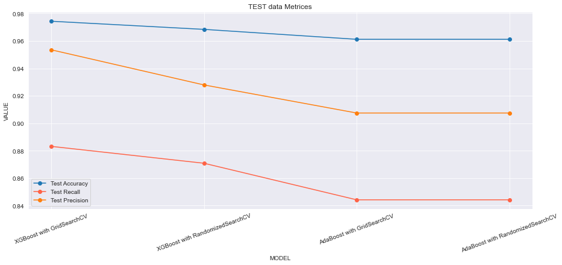

```python
fig, ax = plt.subplots(figsize=(15,6))
ax.set_xlabel("MODEL")
ax.set_ylabel("VALUE")
ax.set_title("TEST data Metrices")
ax.plot(comparison_frame['Model'], comparison_frame['Test_Accuracy'], marker='o', label="Test Accuracy")
ax.plot(comparison_frame['Model'], comparison_frame['Test_Recall'], marker='o', label="Test Recall",color='tomato')
ax.plot(comparison_frame['Model'], comparison_frame['Test_Precision'], marker='o', label="Test Precision")
ax.legend()
plt.xticks(rotation=20)
plt.show()
```

## Insights

# Actionable Insights & Recommendations

- Bank sould look into why Post graduates and higher education are leaving bank at a higher tae then everyone else.
- More products should be offereed to custmers, thats helps them stay.
- Higher revoving balance leads to lower cutomer attrition
- Customers with higher salaries are leaving ban, tis shold be looked into.
- Customers who have bee inactive for a while are potiential leavers, they shold be looked int
- Banks should have asystem to understand why customers with moy, education and gae are not intertested in staying.
- Banks should have asystem to understand why customers with moy, education and gae are not intertested in staying.